# MNIST With a Twist (Literally)

# Interpolation Demonstration

Now, images are generated using the rotations 0, 10, 20, 30, 40, 50, 60, 70, and 80 degrees - note that of these, none except for 0 degrees, 40 degrees, or 80 degrees were trained on. Unlike above, the noise was removed from the latent space such that all draws of the latent space are the same for each row.

The results here seem to be more in favor of the network memorizing than really learning the rotations - 0 degrees and 10 degrees look very similar, as do 30/40/50 degrees and 60/70/80 degrees. The network seems to map to the nearest increment of 40, rather than truly interpolating.

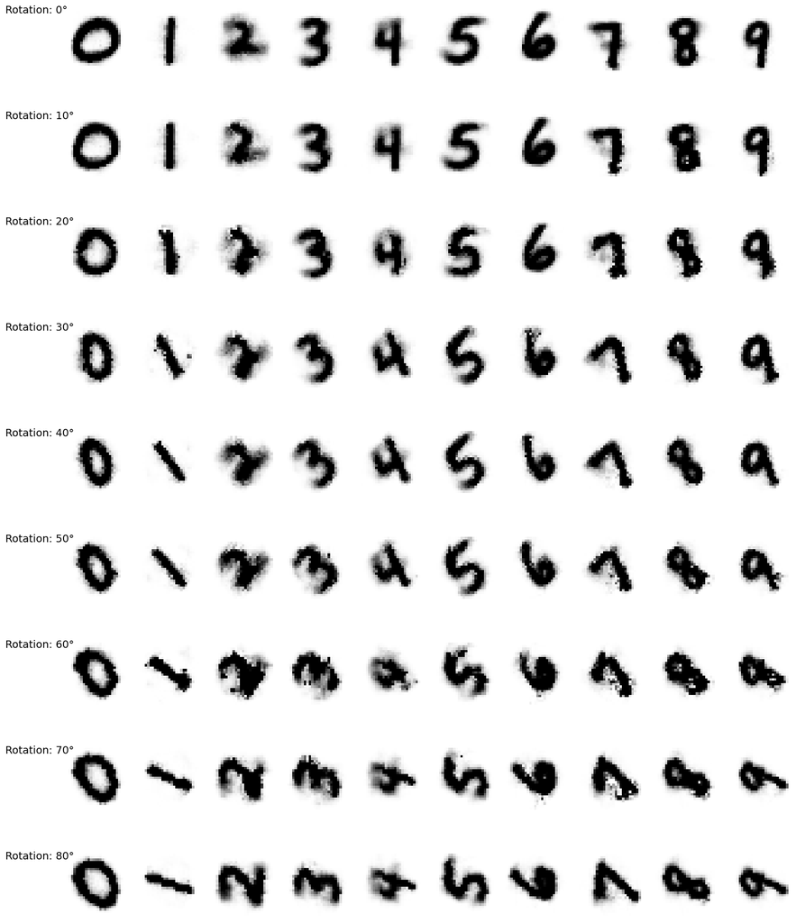

```python
import torch
import matplotlib.pyplot as plt
import numpy as np
import time

# Create the main figure - adjust height for 9 rows (45-degree increments)
fig, axes = plt.subplots(9, 10, figsize=(15, 18))

# Generate images with different rotations every 45 degrees (including 360)
rotations = [0, 10, 20, 30, 40, 50, 60, 70, 80] # 9 rotation angles

for row, rotation_angle in enumerate(rotations):
    # Add a row label for the rotation angle
    plt.figtext(0.01, 0.97 - (row * 0.11), f"Rotation: {rotation_angle}°",
                fontsize=14, va='center', ha='left')

    # Generate different digits for this rotation
    for col in range(10):
        # Random latent vector
        z = torch.randn(1, latent_dim)*0
        z_soft = torch.softmax(z, 1)

        # Set digit (0-9)
        digit = col
        batch_label = torch.tensor([digit * 100 - 450])

        # Set rotation
        rotation_label = torch.tensor([rotation_angle / 40 * 10 - 40])

        # Format tensors properly
        batch_label = batch_label.unsqueeze(1).expand(-1, 1)
        rotation_label = rotation_label.unsqueeze(1).expand(-1, 1)

        # Generate image
        reconstructed_image = vae.decoder(torch.cat([z_soft, batch_label, rotation_label], dim=1))

        # Plot in the grid
        axes[row, col].imshow(reconstructed_image.detach().numpy().squeeze(), cmap='gray')
        axes[row, col].axis('off')

# Adjust layout
plt.tight_layout()
plt.subplots_adjust(left=0.08, hspace=0.05)  # Make room for rotation labels and reduce vertical spacing


# Save the figure
plt.savefig('C:/Users/defgi/Documents/Website/assets/images/mnist_output.jpg', dpi=150, bbox_inches='tight')
plt.show()
```

# Conclusion

Overall, while it was rewarding to train a custom conditional VAE on a classic dataset and test out an idea, it didn't seem like generalizability was achieved. This doesn't mean a network can't accomplish this - if I were to try again, I would code rotations using a trigonmetric cyclical function, increase the number of increments to try, and embed the digit as a high-dimensional vector instead of submitting it as a single real-valued number. But for the architecture actually trained, memorization was favored.